# Lab 6: Multiple Comparisons & Factorial ANOVA

PSC 103B

Marwin Carmo

## Packages and data

First of all, lets load tidyverse

```r
library(tidyverse)
```

And read in the data

```r
nerdy <- read_csv('NPAS_Lab6.csv')
```

## ANOVA recap

- Rerun one-way anova from last week’s lab on new dataset:

```r
my.anova <- lm(formula = nerdy_selfreport ~ continent, data = nerdy)

anova(my.anova)
```

```
Analysis of Variance Table

Response: nerdy_selfreport
           Df  Sum Sq Mean Sq F value  Pr(>F)
continent   4   27.05  6.7615  3.2209 0.01222 *
Residuals 995 2088.73  2.0992
---
Signif. codes:  0 '***' 0.001 '**' 0.01 '*' 0.05 '.' 0.1 ' ' 1
```

## ANOVA recap

- Rerun linear contrasts with new means

```r
nerdy %>%
  group_by(continent) %>%
  summarize(M = mean(nerdy_selfreport))
```

```
# A tibble: 5 × 2
  continent     M
  <chr>     <dbl>
1 Africa     5.33
2 Americas   5.52
3 Asia       5.1
4 Europe     5.20
5 Oceania    5.50
```

## ANOVA recap

- Contrast 1- Americas and Europe

```r
psi_1 <- 1 * 5.52 + (-1) * 5.20
ss_psi1 <- (200 * psi_1^2) / (1^2 + (-1)^2)
ms_psi1 <- ss_psi1 / 1
f_psi1 <- ms_psi1 / 2.0992
pf(f_psi1, df1 = 1, df2 = 995, lower.tail = FALSE)
```

```
[1] 0.02742767
```

- Contrast 2- Asia vs all other groups

```r
psi_2 <- -0.25 * (5.33 + 5.52 + 5.20 + 5.50) + 1 * 5.1
ss_psi2 <- (200 * psi_2^2) / ((-0.25)^2 + (-0.25)^2 + (-0.25)^2 + (-0.25)^2 + 1^2)
ms_psi2 <- ss_psi2 / 1
f_psi2 <- ms_psi2 / 2.0992
pf(f_psi2, df1 = 1, df2 = 995, lower.tail = FALSE)
```

```
[1] 0.01223147
```

## Multiple Comparisons: A Priori

- In this scenario, the comparisons you conduct had been planned in advance, before you even looked at the data.
- These are known as *a priori* tests.
- Because you did not make your decision of which comparisons to make based on the data you only have to correct for the tests that you actually conducted.

## Multiple Comparisons: A Priori

- Assume that I had planned to do my 2 comparisons in advance
- Then to ensure that the total error rate for my comparisons remains below 5%, I divide 5% by the number of tests that I conduct.

```r
.05/2
```

```
[1] 0.025
```

- Now I compare my p-values from last week’s comparisons to this new alpha

```r
pf(f_psi1, df1 = 1, df2 = 995, lower.tail = FALSE)
```

```
[1] 0.02742767
```

```r
pf(f_psi2, df1 = 1, df2 = 995, lower.tail = FALSE)
```

```
[1] 0.01223147
```

## Multiple Comparisons: Post-Hoc

- Let’s move to a scenario where I *didn’t* plan those two comparisons in advance.
- Instead, I chose to make those comparisons based on how the means looked - for example, the mean of Asia appears to be lower than the other continents.
- This is known as a **post-hoc test**, and is typically more exploratory.
- I now have to correct for all the tests I could have chosen to do if my data had looked any different.

## Multiple Comparisons: Post-Hoc

- There are two common post-hoc tests: Scheffe’s and Tukey’s.
- We use the Scheffe correction if our comparisons involve any combination of complex *and* pairwise contrasts.
- And the Tukey correction if we’re only interested in the pairwise comparisons

## Multiple Comparisons: Scheffe’s post-Hoc

- Since we have one complex contrast and one pairwise contrast, we use the Scheffe correction.
- It involves calculating a new critical F value that you compare your calculated F statistic to.
- The new critical F value is $(J-1)\times F_{\alpha}$
- $F_{\alpha}$ is the value that cuts off 5% of the F distribution with df (J-1, N-J).

```r
# We had 5 groups, and 1000 participants, so our new critical F is
J <- 5
N <- 1000
(J-1)*qf(.05, df1 = 4, df2 = N-J, lower.tail = FALSE)
```

```
[1] 9.523503
```

## Multiple Comparisons: Scheffe’s post-Hoc

- Compare our calculated F statistics to this value:
- Americas vs Europe:
  - 4.88 < 9.52
- Asia vs all:
  - 6.3 < 9.5
- Do not reject $H_0$ of both tests.

## Multiple Comparisons: Tukey’s Honest Significant Difference (HSD)

- What if we were only interested in pairwise comparisons such as Europe vs the Americas, and Americas vs. Oceania?
- We can do a Tukey correction (a.k.a Tukey’s HSD test).
- Tukey correction is considering a smaller family of tests than Scheffe, so it typically has higher power.

## Multiple Comparisons: Tukey’s HSD

- To run the Tukey’s test in R we need a different function for the ANOVA, the `aov()` function:

```r
# the input is the same as the lm() function from last week
my.anova <- aov(nerdy_selfreport ~ continent, data = nerdy)
```

- We can use `summary()` to get the ANOVA table .

```r
summary(my.anova)
```

```
             Df Sum Sq Mean Sq F value Pr(>F)
continent     4     27   6.761   3.221 0.0122 *
Residuals   995   2089   2.099
---
Signif. codes:  0 '***' 0.001 '**' 0.01 '*' 0.05 '.' 0.1 ' ' 1
```

Now, for the Tukey test, we use the `TukeyHSD()` function:

```r
TukeyHSD(my.anova)
```

```
  Tukey multiple comparisons of means
    95% family-wise confidence level

Fit: aov(formula = nerdy_selfreport ~ continent, data = nerdy)

$continent
                   diff          lwr         upr     p adj
Americas-Africa   0.190 -0.205945278  0.58594528 0.6842103
Asia-Africa      -0.230 -0.625945278  0.16594528 0.5057942
Europe-Africa    -0.125 -0.520945278  0.27094528 0.9103963
Oceania-Africa    0.175 -0.220945278  0.57094528 0.7468648
Asia-Americas    -0.420 -0.815945278 -0.02405472 0.0312756
Europe-Americas  -0.315 -0.710945278  0.08094528 0.1903834
Oceania-Americas -0.015 -0.410945278  0.38094528 0.9999741
Europe-Asia       0.105 -0.290945278  0.50094528 0.9508049
Oceania-Asia      0.405  0.009054722  0.80094528 0.0420624
Oceania-Europe    0.300 -0.095945278  0.69594528 0.2337218
```

## Factorial ANOVA

- Up until now, we’ve done a one-way ANOVA, where we only had a single grouping variable.
- What would we do if we had more than one grouping variable?
- With the factorial ANOVA we can see the effect of each grouping variable on their own, but also their potential interaction.

## Factorial ANOVA

Factorial ANOVA allow us examine in one test:

- is there an effect of Grouping Variable 1 (at least one mean is different in those groups)?
- is there an effect of Grouping Variable 2?
- is there an interaction between the 2 variables (so that the effect of Grouping Variable 1 depends on Grouping Variable 2, or vice versa)?

## Factorial ANOVA

- **Main effect**: When the average outcome changes consistently across different levels of one factor, regardless of the other factors. Imagine studying how exercise and diet affect weight loss. If people lose more weight with exercise regardless of their diet, that’s a main effect of exercise.
- **Interaction**: When the effect of one factor changes depending on the level of another factor. Back to the exercise and diet example, if exercise leads to more weight loss only for people on a specific diet, there’s an interaction.

## Factorial ANOVA

- The NPAS dataset also had information on participants’ biological sex (`gender`).
- What if we were interested in whether continent *and* sex had significant effects on self-reported nerdiness?
- Let’s look at the means of each group.

```r
nerdy %>%
  group_by(continent) %>%
  summarize("Mean" = mean(nerdy_selfreport))
```

```
# A tibble: 5 × 2
  continent  Mean
  <chr>     <dbl>
1 Africa     5.33
2 Americas   5.52
3 Asia       5.1
4 Europe     5.20
5 Oceania    5.50
```

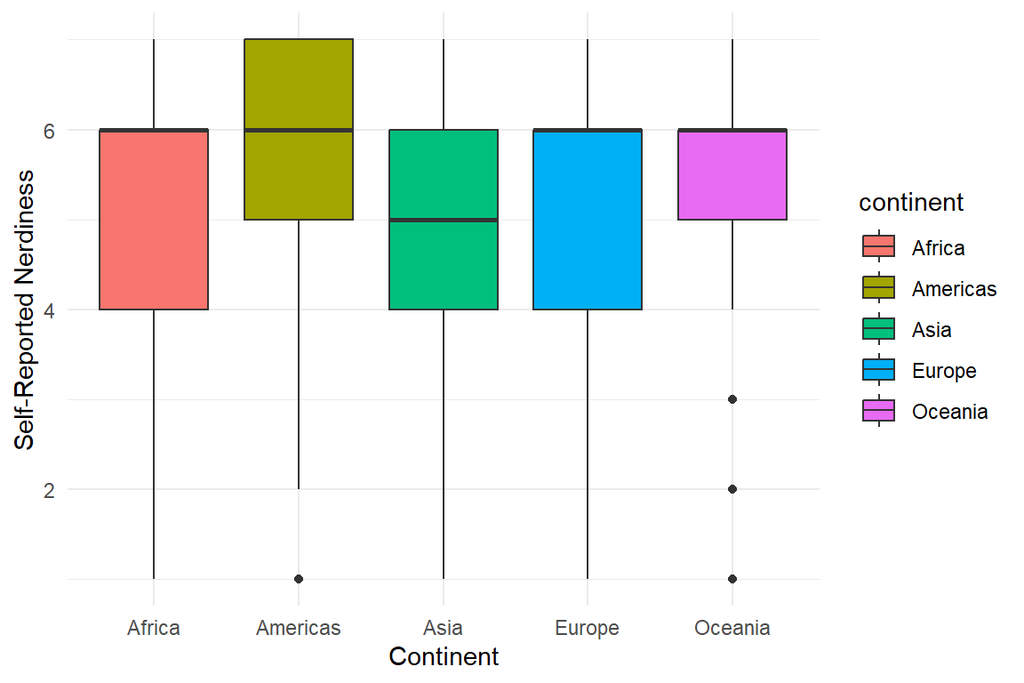

```r
nerdy %>%
  group_by(gender) %>%
  summarize("Mean" = mean(nerdy_selfreport))
```

```
# A tibble: 2 × 2
  gender  Mean
  <chr>  <dbl>
1 Female  5.45
2 Male    5.22
```

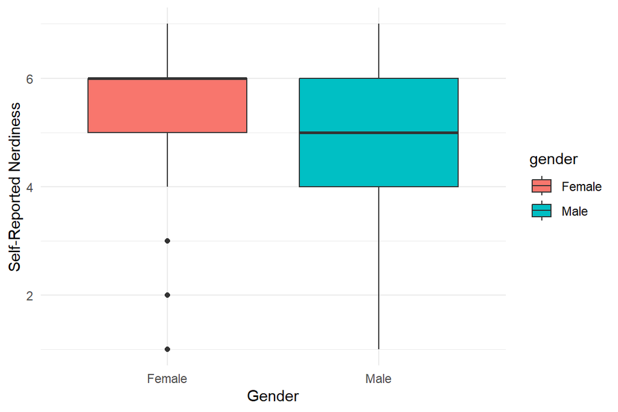

```r
nerdy %>%
  group_by(continent, gender) %>%
  summarize("Mean" = mean(nerdy_selfreport))
```

```
# A tibble: 10 × 3
# Groups:   continent [5]
   continent gender  Mean
   <chr>     <chr>  <dbl>
 1 Africa    Female  5.29
 2 Africa    Male    5.37
 3 Americas  Female  5.58
 4 Americas  Male    5.46
 5 Asia      Female  5.22
 6 Asia      Male    4.98
 7 Europe    Female  5.48
 8 Europe    Male    4.93
 9 Oceania   Female  5.66
10 Oceania   Male    5.35
```

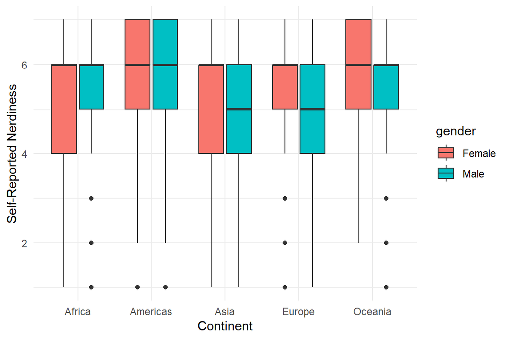

## Factorial ANOVA

- Hypothesis for the main effect of continent
  - $H_0: \mu_{Americas} = \mu_{Africa} = \mu_{Asia}= \mu_{Europe}= \mu_{Oceania}$
  - $H_A$: At least one mean is significantly different from the rest.
- Hypothesis for the main effect of gender
  - $H_0: \mu_{female} = \mu_{male}$
  - $H_A$: $H_0: \mu_{female} \neq \mu_{male}$ (note that because there are only 2 groups, we can be more specific with our alternative hypothesis).

## Factorial ANOVA

- For the interaction of continent x gender (we can write this in words):
  - $H_0$: There is no interaction between continent and gender.
  - $H_A$: There is an interaction between continent and gender.

## Factorial ANOVA

Now let’s run the factorial ANOVA test in `R`.

We “multiply” our two predictors to include an interaction between them.

```r
my.anova2 <- lm(nerdy_selfreport ~ continent * gender, data = nerdy)
anova(my.anova2)
```

```
Analysis of Variance Table

Response: nerdy_selfreport
                  Df  Sum Sq Mean Sq F value  Pr(>F)
continent          4   27.05  6.7615  3.2418 0.01180 *
gender             1   13.00 12.9960  6.2309 0.01272 *
continent:gender   4   10.85  2.7135  1.3010 0.26782
Residuals        990 2064.88  2.0857
---
Signif. codes:  0 '***' 0.001 '**' 0.01 '*' 0.05 '.' 0.1 ' ' 1
```

## Write up these results

We conducted a 5 (Continent: Americas, Asia, Africa, Europe, and Ocenia) x 2 (Gender: Male, Female) factorial ANOVA. There was a statistically significant effect of continent (F(4, 990) = 3.24, *p* = .01). There was also a statistically significant effect of gender (F(1, 990) = 6.23, *p* = .01), such that females self-reported as being more nerdy (M = 5.45, SD = 1.36) than males (M = 5.22, SD = 1.54). The interaction between continent and gender was not significant, F(4, 990) = 1.30, *p* = .27.

## Computing the Bayes Factor

```r
library(BayesFactor)

nerdy$continent <- as.factor(nerdy$continent)
nerdy$gender <- as.factor(nerdy$gender)

anovaBF(nerdy_selfreport ~ continent * gender, data = nerdy, whichModels="top")
```

```
Bayes factor top-down analysis
--------------
When effect is omitted from continent + gender + continent:gender , BF is...
[1] Omit continent:gender : 29.81944  ±4.2%
[2] Omit gender           : 0.6330585 ±3.33%
[3] Omit continent        : 2.324884  ±3.55%

Against denominator:
  nerdy_selfreport ~ continent + gender + continent:gender
---
Bayes factor type: BFlinearModel, JZS
```

## Now you try

**Exercise**

Run a factorial ANOVA using `nerdy_scale` as your outcome and testing the interaction between the penguin `gender` and `continent` . What can you conclude? Practice writing up the null and alternative hypothesis.

[figure not shown]

PSC 103B - Statistical Analysis of Psychological Data